# Lab 1

Author

Jasmine Cabrera

**3.4: Check the data documentation.**

Before the code chunk, create a section header (using #s) that describes the contents of the section.

# Cars Data Set

Use the information that pops up in your Help pane in RStudio to fill in the blanks below. Add the questions and your responses after the R code chunk.

**Question:** This data set contains information about ___. The data was collected in ___. It has ___ rows and ___ variables.

**Answer:** This data set contains information about the speed of cars and the distances taken to stop. The data was collected in the 1920s. It has 50 rows and 2 variables.

**4.0: Creating a Plot.**

Create another section header stating what is included in this section.

# Pressure Data Set Plot

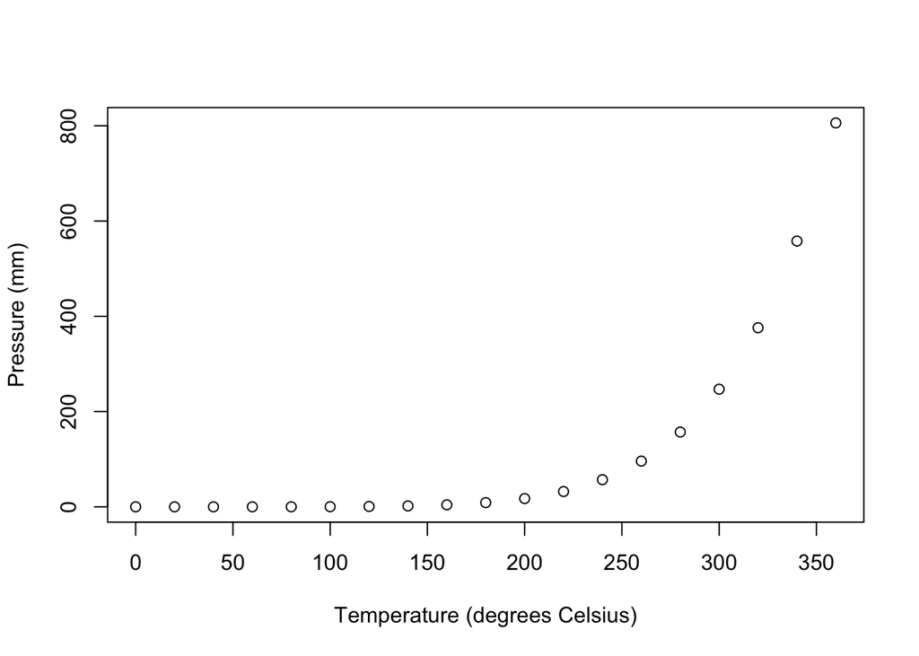

**Question:** Similar to what you did before with the cars data set, look up the help file on the pressure data set to determine what units temperature and pressure were measured in.

**Answer:** Temperature was measured in degrees Celsius and pressure was measured in mm.

**4.1: Inserting a New Code Chunk.**

Type command + option + i:

**4.2: Creating and Discussing Visualizations.**

# Plotting Cars Data Set

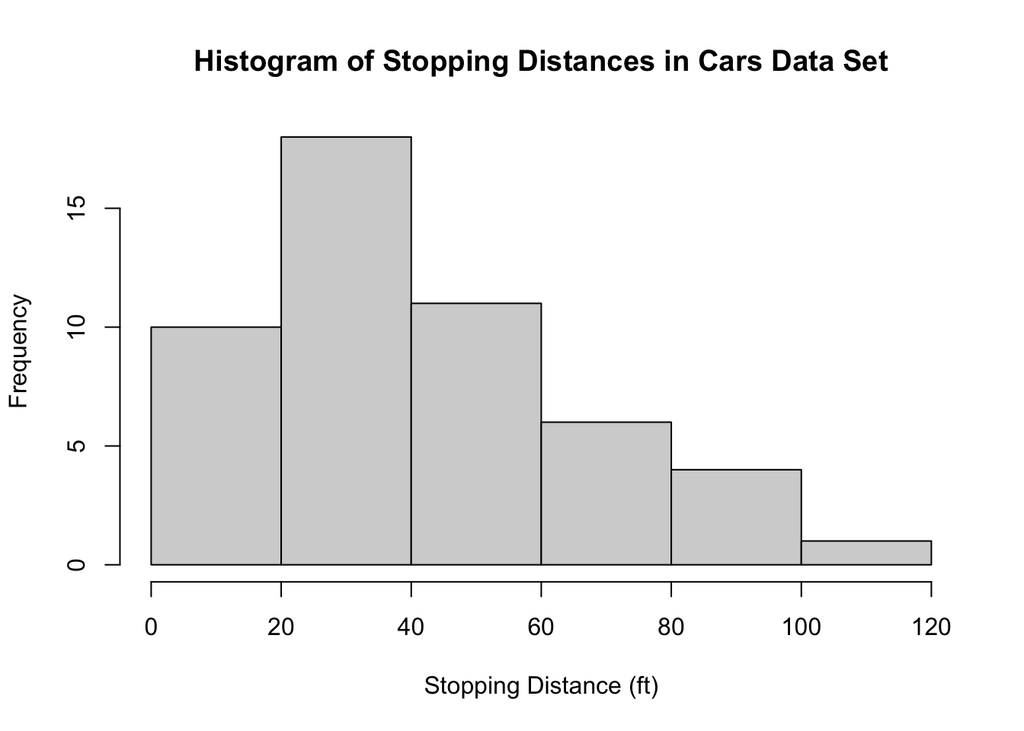

```r
#step 1: extract the distance column of the cars dataset and save it into a new object named dist
dist <- cars[ , 2]

#step 2: plot the distribution of the stopping distances (contained in dist)
hist(dist , xlab = "Stopping Distance (ft)" , main = "Histogram of Stopping Distances in Cars Data Set")
```

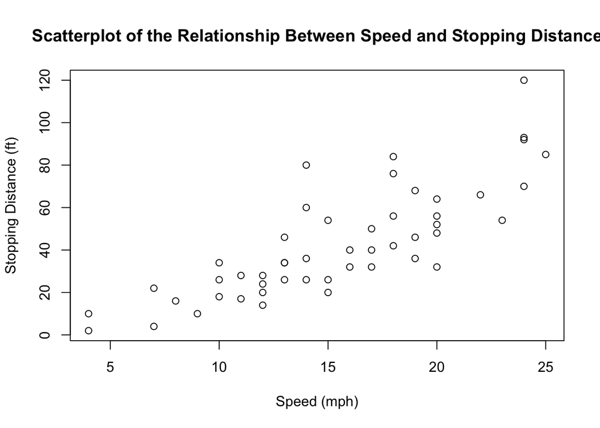

```r
#step 3: create a second plot, a scatterplot, visualizing the relationship between stopping distance and speed
plot(cars , xlab = "Speed (mph)" , ylab = "Stopping Distance (ft)" , main = "Scatterplot of the Relationship Between Speed and Stopping Distance")
```

Step 5: Create a bulleted list of two aspects of the plots you would like to improve.

- Title
- Axis Labels